# useR! 2019 Recap

Ezgi Karaesmen & Katie Sasso-Schafer

Thu Aug 15 2019

## Introduction

This is a summary of interesting packages/function we learned at useR! 2019 conference. All presentations are still available at the conference website and can be found here: [user2019.fr/talk_schedule](http://www.user2019.fr/talk_schedule/)

## Selected talks

### Package flextable: a grammar to produce tabular reporting from R - Quentin Fazilleau

See details davidgohel.github.io/flextable/articles/format.html

```r
library(flextable)
library(tidyverse)
library(tidyr)
library(usethis)

ft <- flextable(head(mtcars))
ft <- color(ft, i = ~ drat > 3, j = ~ vs + am, color = "red")
ft <- bg(ft, i = ~ wt < 3, j = ~ mpg, bg = "#EFEF99")
ft <- bold(ft, i = 2:4, j = "cyl", bold = TRUE)
ft
```

| mpg | cyl | disp | hp | drat | wt | qsec | vs | am | gear | carb |
| --- | --- | --- | --- | --- | --- | --- | --- | --- | --- | --- |
| 21.000 | 6.000 | 160.000 | 110.000 | 3.900 | 2.620 | 16.460 | 0.000 | 1.000 | 4.000 | 4.000 |
| 21.000 | 6.000 | 160.000 | 110.000 | 3.900 | 2.875 | 17.020 | 0.000 | 1.000 | 4.000 | 4.000 |
| 22.800 | 4.000 | 108.000 | 93.000 | 3.850 | 2.320 | 18.610 | 1.000 | 1.000 | 4.000 | 1.000 |
| 21.400 | 6.000 | 258.000 | 110.000 | 3.080 | 3.215 | 19.440 | 1.000 | 0.000 | 3.000 | 1.000 |
| 18.700 | 8.000 | 360.000 | 175.000 | 3.150 | 3.440 | 17.020 | 0.000 | 0.000 | 3.000 | 2.000 |
| 18.100 | 6.000 | 225.000 | 105.000 | 2.760 | 3.460 | 20.220 | 1.000 | 0.000 | 3.000 | 1.000 |

### Connecting R/R Markdown and Microsoft Word using StatTag for Collaborative Reproducibility - Leah Welty

[video not shown]

To download and get more details on how to use it go to https://sites.northwestern.edu/stattag/

### `auth0`: Secure Authentication in Shiny with Auth0 - Julio Trecenti

Free autehtication service for Shiny apps!  
See github.com/curso-r/auth0

### ggwordcloud: a word cloud geometry for ggplot2 - Erwan Le Pennec

https://github.com/lepennec/ggwordcloud

```r
library(ggwordcloud)
data("love_words_small")
head(love_words_small)
```

```
## # A tibble: 6 x 4
##   lang  word  native_speakers speakers
##   <chr> <chr>           <dbl>    <dbl>
## 1 zh    愛             1200      1200
## 2 en    Love            400       800
## 3 es    Amor            480       555
## 4 ar    حب              245       515
## 5 hi    प्यार            322       442
## 6 fr    Amour            76.8     351.
```

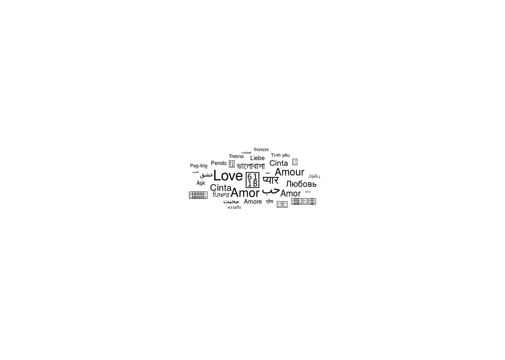

```r
set.seed(42)
ggplot(love_words_small, aes(label = word, size = speakers)) +
  geom_text_wordcloud() +
  theme_minimal()
```

### mlr3: A new modular framework for machine learning with R - Michel Lang

Nice alternative to Caret

[Github](https://github.com/mlr-org/mlr3)

[Book (work in progress)](https://mlr3book.mlr-org.com/use-cases.html)

## Tidyverse news

### n() cool #dplyr things - Romain Francois

[slides](https://speakerdeck.com/romainfrancois/n-cool-number-dplyr-things)

Group function updates

```r
?group_modify
?group_split
```

Column wise

- Replace group_by and summarise. Action and selection at the same time is what you do with group_by and summarise
- Which summarise_at we can separate concept of selection and function
  - Less error prone. Only have to change the function in one place
  - Can do this with your own function

```r
iris %>%
  group_by(Species) %>%
  summarise_at(
    vars(contains("Petal"), contains("Sepal")),
         mean)
```

```
## # A tibble: 3 x 5
##   Species    Petal.Length Petal.Width Sepal.Length Sepal.Width
##   <fct>             <dbl>       <dbl>        <dbl>       <dbl>
## 1 setosa             1.46       0.246         5.01        3.43
## 2 versicolor         4.26       1.33          5.94        2.77
## 3 virginica          5.55       2.03          6.59        2.97
```

### DRY out your workflow with the usethis package - Jenny Bryan

Workflow functions directly to be called

```r
?create_package()
?create_project()
```

use_this demo videos

```r
?use_github()
?use_mit_license()
```

good functions for workshops and teaching

```r
?usethis::use_course()
?usethis::use_zip()
```

### Reusing tidyverse code, the easy way - Lionel Henry

**Tidy Eval**

- Powers data masking from the rlang package
- Flexible and robust
- `{{2 + 2}}` replacing !! and enquo
- Need latest version of rlang

[tidyeval](https://tidyeval.tidyverse.org/)

[slides here](https://speakerdeck.com/lionelhenry/reusing-tidyverse-code)

### Enhancements to data tidying - Hadley Wickham

New versions of gather and spread!

- Two key tidyr functions for solving
  - pivot_longer (previously gather) columns
  - pivot_wider (previously spread)
- Available on github for now

[interactive chart not shown]

Example

```r
# devtools::install_github("tidyverse/tidyr")
# devtools::install_github("chrk623/dataAnim")
library(dataAnim)
library(tidyr)

#pivot_longer
datoy_wide
```

```
##    Name English Maths
## 1   Ben    19.0  58.5
## 2   Sam     6.7  51.8
## 3 Sarah    14.9  45.1
```

```r
datoy_wide %>%
  pivot_longer(cols = English:Maths, names_to = 'Subject',
             values_to = "Score")
```

```
## # A tibble: 6 x 3
##   Name  Subject Score
##   <chr> <chr>   <dbl>
## 1 Ben   English  19
## 2 Ben   Maths    58.5
## 3 Sam   English   6.7
## 4 Sam   Maths    51.8
## 5 Sarah English  14.9
## 6 Sarah Maths    45.1
```

```r
#pivot_wider
datoy_long
```

```
##   Name Subject Score
## 1  Ben   Maths  10.0
## 2  Ben English  63.7
## 3  Sam   Maths  52.9
## 4  Sam English  75.6
## 5 Alex   Maths  88.8
## 6 Alex English  92.2
```

```r
datoy_long %>%
  pivot_wider(names_from = Subject, values_from = Score)
```

```
## # A tibble: 3 x 3
##   Name  Maths English
##   <chr> <dbl>   <dbl>
## 1 Ben    10      63.7
## 2 Sam    52.9    75.6
## 3 Alex   88.8    92.2
```

Animations to show what they do in dataAnim

```r
# devtools::install_github("tidyverse/tidyr")
# devtools::install_github("chrk623/dataAnim")

library(dataAnim)
gather_anim(
   key = "Subject",
   value = "Score",
   col = c("English", "Maths"),
   data = datoy_wide
 )
```

[interactive chart not shown]